# Chapter 2: Statistical Inference - Problem Set

# 1 Introduction

For this tutorial we are using the Ames, IA data set as used in the previous problem set.

For this tutorial, we will use the following packages:

```r
library(tidyverse)
```

# 2 Problem 1. Read the ames.csv data set.

```r
ames <- read.csv('./ames.csv', header = T, stringsAsFactors = F, sep = ',')
```

Take three random samples of the ames data set of the following size and seeds (we’ll use a set seed for each so we can compare results):

- Sample 1: N = 10, seed = 2489
- Sample 2: N = 20, seed = 571
- Sample 3: N = 30, seed = 2979

Recall that you set the seed by the command `set.seed(SeedNumber)` right before employing a random number.

Amendment, 7 April 2020: We did not discuss this in class, but we should sample **with** replacement in general to preserve independent, identically distributed distributions. The results below show my error (sampling without replacement). We noted this in a class discussion on 6 April, 2020 as discussed in this document .

```r
# We can sample using the dplyr command sample_n().

set.seed(2489)
sample.1 <- sample_n(ames, 10)

set.seed(571)
sample.2 <- sample_n(ames, 20)

set.seed(2979)
sample.3 <- sample_n(ames, 30)
```

# 3 Confidence Intervals

Find the 90% confidence interval for the mean sale price (i.e., `ames$SalePrice`) for each of the three samples. Plot the results. Assuming the entire data set is the population, plot the true mean.

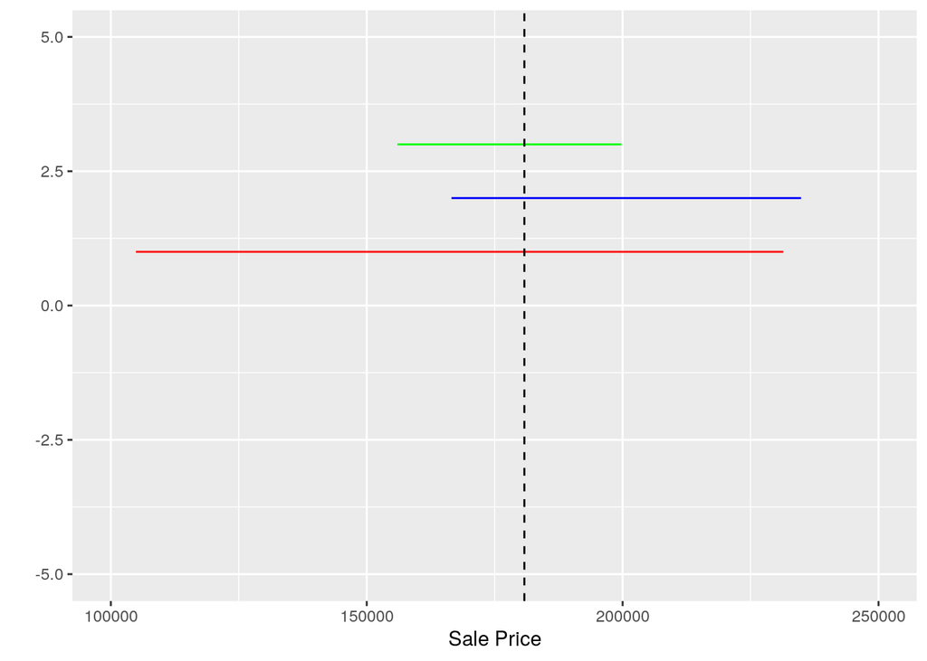

```r
# Recall the function t.test produces the confidence interval, the default for this function is conf.level = .95, so we have to set it.
sample.1.t.test <- t.test(sample.1$SalePrice, conf.level = .9)
sample.2.t.test <- t.test(sample.2$SalePrice, conf.level = .9)
sample.3.t.test <- t.test(sample.3$SalePrice, conf.level = .9)


# We can plot these using a line segment - geom_segment.  We can plot the true mean as a vertical line
ggplot() +
  # geom_segment requires an x, xend, y, and yend.
  geom_segment(aes(x = sample.1.t.test$conf.int[[1]], y = 1, xend = sample.1.t.test$conf.int[[2]], yend = 1), color = 'red') +
  geom_segment(aes(x = sample.2.t.test$conf.int[[1]], y = 2, xend = sample.2.t.test$conf.int[[2]], yend = 2), color = 'blue') +
  geom_segment(aes(x = sample.3.t.test$conf.int[[1]], y = 3, xend = sample.3.t.test$conf.int[[2]], yend = 3), color = 'green') +
  geom_vline(xintercept = mean(ames$SalePrice), lty = 2) +
  xlim(c(100000, 250000)) + ylim(c(-5, 5)) + # This just makes the graph look slightly nicer
  xlab('Sale Price') + ylab('')
```

What can you conclude about the mean sale price from these confidence intervals? How would you interpret any instances of the true mean falling outside of the confidence interval?

```
We see several things:
- First, though all of the intervals have the same level of significance, the trend is that the confidence interval gets larger with fewer observations.
- Second, in this case we see that all of the CIs include the true mean, which we would expect 9 out of 10 times, but we can see how it is possible for the true mean to fall outside of a CI.
```

# 4 Hypothesis Testing

## 4.1 Hypothesis Test 1: Test of Normality

Based on Sample 3, is it likely that the distribution of house sale prices follows a normal curve? Clearly articulate your null and alternative hypothesis, what your test is, what level of significance is, what your results are, and what you conclude (hint, this requires a test different from the very common t test, but the appropriate test was listed as a standard test in R in the tutorial).

```r
# - Our null hypothesis is that the data *is* normally distributed.  Our alternative is that it is not.
# - We will use the Shapiro Wilk Test, `shapiro.test()`.
# - We will use a 95% (i.e., 1 - .05) level of significance.

# We can test for normality using the shapiro wilk test with the command `shapiro.test()`
shapiro.test(sample.3$SalePrice)
```

```
##
##  Shapiro-Wilk normality test
##
## data:  sample.3$SalePrice
## W = 0.90528, p-value = 0.01134
```

```r
# We see that the p-value is .01134 is less than .05, so we reject the null hypothesis and conclude that the distribution of sale prices of homes is not normally distributed.
```

Plot the distribution of sale prices of Sample 3 and see if this generally agrees with what you learned from your hypothesis test above.

How does this compare to a presumed normal distribution (hint: you can check this with a qqplot or overlaying the observed distribution on a normal distribution)?

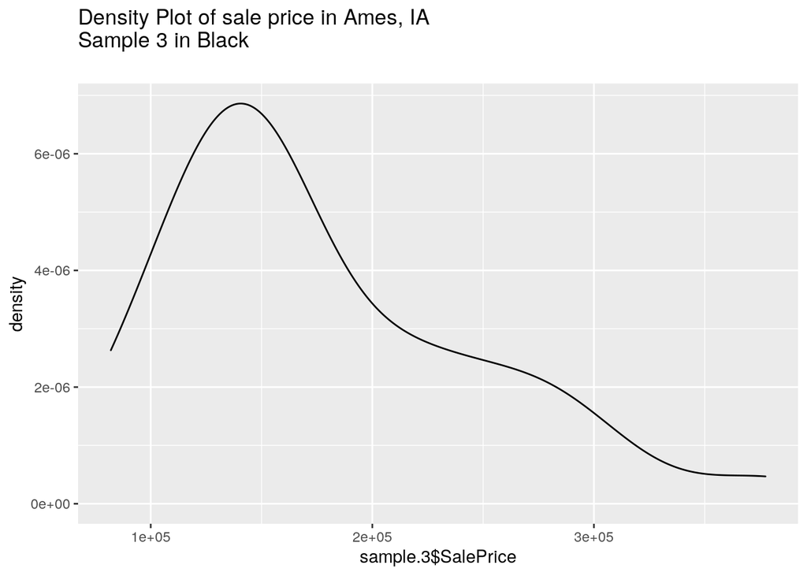

```r
# We can approximately plot the distribution using geom_density
ggplot() +
    geom_density(aes(x = sample.3$SalePrice), color = 'black') +
    ggtitle('Density Plot of sale price in Ames, IA\nSample 3 in Black\n')
```

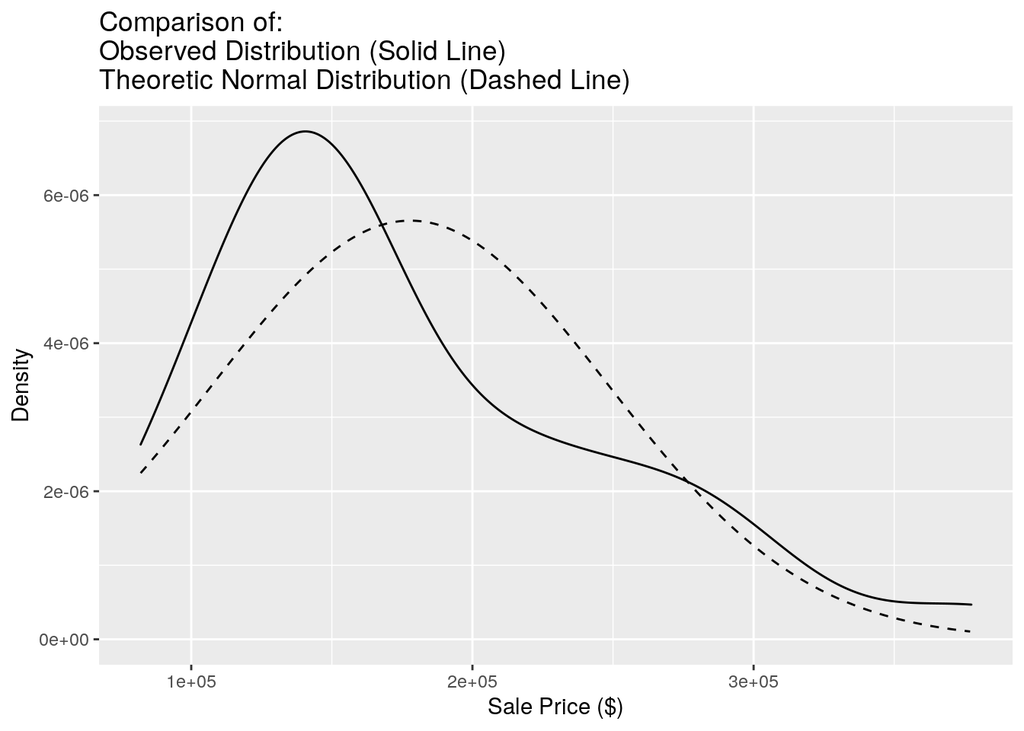

```r
# This looks clearly not normal, so it makes sense that we rejected the null hypothesis that the data was normally distributed.  We can see this even more clearly by plotting a normal distribution with the sample mean and standard deviation on top of this

ggplot() +
  geom_line(aes(x = seq(min(sample.3$SalePrice), max(sample.3$SalePrice), by = 1000),
                y =  dnorm(seq(min(sample.3$SalePrice), max(sample.3$SalePrice), by = 1000),
                           mean = mean(sample.3$SalePrice), sd = sd(sample.3$SalePrice))), lty = 2) +
  geom_density(aes(x = sample.3$SalePrice), color = 'black') +
  xlab('Sale Price ($)') + ylab('Density') +
  ggtitle('Comparison of:\nObserved Distribution (Solid Line)\nTheoretic Normal Distribution (Dashed Line)')
```

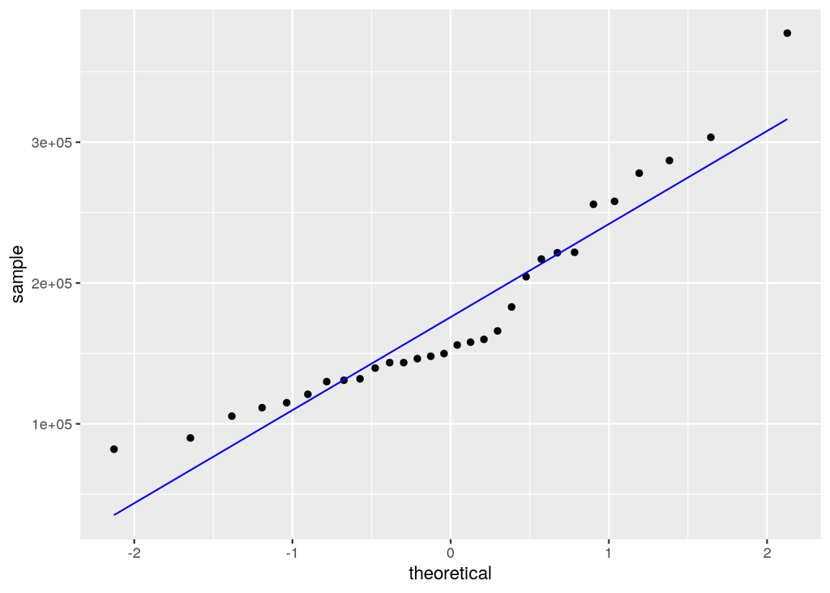

```r
# We can also do this with a so called QQ Plot which is simply comparison between the observed values and the theoretical distribution (in our case a normal distribution).  If the data is perfectly normally distributed, the resulting observations will be plotted as a straight line

ggplot() +
  geom_qq(aes(sample = sample.3$SalePrice)) + # Plots the points in a QQ manner
  geom_qq_line(aes(sample = sample.3$SalePrice), color = 'blue')  # Plots the QQ line
```

```r
# Note that the observed distribution is clearly not normal by either measure.  That stated, qqplots and comparing the shape of the observed and theoretic distributions are rather imprecise ways of assessing normality.  A specific hypothesis test, like Shapiro Wilk is more precise and repeatable.
```